# Nuisance Correction

## Evaluation of White Matter PCs for Nuisance Regression

### 3/30/17 Deliverable

Goal: Determine if the nuisance correction method of removing the first five principal components of the white matter from the fMRI data is statistically supported.

### Why an F-test?

An F-test of overall significance in regression "compares the fits of different linear models." This test as we apply it compares the model from the white matter components to an "intercept-only model,... a regression model that contains no predictors." The null hypothesis is therefore that the white matter model and intercept-only model are equal with the alternative hypothesis being that the fit of the intercept-only model is "significantly reduced" compared to the white matter model. Thus if we obtain a p-value lower than the significance level we will specify as 0.05, then we reject the null hypothesis and conclude that the white matter model provides a better fit than the intercept-only model, which means the white matter model "predicts the response variable better than the mean of the response." [More info](http://blog.minitab.com/blog/adventures-in-statistics-2/what-is-the-f-test-of-overall-significance-in-regression-analysis)

### Description

We first calculate the beta values of the GLM of the white matter components. The GLM system of equations can be described as: $$y = Xb + e$$ where $X$ is the design matrix, $b$ is the beta value vector, and $e$ is the added error vector. The values predicted by the model are $\hat{y} = Xb$. We then calculate the sum of squares for the model as $SSM = \sum_{i=1}^n (\hat{y_i}-\bar{y})^2$ and the sum of squares for error as $SSE = \sum_{i=1}^n (y_i-\hat{y_i})^2$. We calculate an $F$ statistic with $DFM = p-1$ degrees of freedom in the numerator and $DFE = n-p$ degrees of freedom in the denominator where $n$ is the number of timesteps and $p$ is the number of regressors. The $F$ statistic is then calculated as follows: $$F_{DFM,DFE} = \frac{SSM \times DFE}{SSE \times DFM}$$ From here, we can use the value of the $F$ statistic and the degrees of freedom to calculate the p-value. A high F-value corresponds to a low p-value.

### Implementation

After running the datasets through the pipeline in order to obtain the registered fMRI images, the following shell script was utilized in order to perform the F-tests on each of the subjects' task data.

```python
#!/bin/bash
# analysis.sh
#$1 = reg_fmri
#$2 = reg_struct

exec 4<$1
exec 5<$2

while read -r reg_fmri <&4 && read -r reg_struct<&5; do
    python analysis.py $reg_fmri $reg_struct
done 4<$1 5<$2
```

The script calls analysis.py which is as follows:

```python
from ndmg.utils import utils as mgu
import nibabel as nb
import numpy as np
import scipy.signal as signal
import scipy.stats as stats
import sys
fmri = sys.argv[1]
amri = sys.argv[2]
amask = '../../FNGS_server/atlases/mask/MNI152_T1-2mm_brain_mask.nii.gz'
an = 1
outdir = './'
lvmask = '../../FNGS_server/atlases/mask/HarvOx_lv_thr25-2mm.nii.gz'
amask_im = nb.load(amask)
amm = amask_im.get_data()
lv_im = nb.load(lvmask)
lvm = lv_im.get_data()
fmri_name = mgu().get_filename(fmri)
anat_name = mgu().get_filename(amri)
nuisname = "".join([anat_name, "_nuis"])
map_path = mgu().name_tmps(outdir, nuisname, "_map")
wmm_path = mgu().name_tmps(outdir, nuisname, "_wm_mask.nii.gz")
er_wmm_path = mgu().name_tmps(outdir, nuisname, "_eroded_wm_mask.nii.gz")
cmd1 = " ".join(["fast -t", str(int(an)), "-n 3 -o", map_path, amri])
mgu().execute_cmd(cmd1)
wm_prob = map_path + "_pve_2.nii.gz"
prob = nb.load(wm_prob)
prob_dat = prob.get_data()
mask = (prob_dat > .99).astype(int)
img = nb.Nifti1Image(mask,header = prob.header,affine = prob.get_affine())
nb.save(img, wmm_path)
mask_img = nb.load(wmm_path)
mask = mask_img.get_data()
for i in range(0, 2):
    erode_mask = np.zeros(mask.shape)
    x, y, z = np.where(mask != 0)
    if (x.shape == y.shape and y.shape == z.shape):
        for j in range(0, x.shape[0]):
            md = mask.shape
            if (mask[x[j],y[j],z[j]] and
                mask[np.min((x[j]+1, md[0]-1)),y[j],z[j]] and
                mask[x[j],np.min((y[j]+1, md[1]-1)),z[j]] and
                mask[x[j],y[j],np.min((z[j]+1, md[2]-1))] and
                mask[np.max((x[j]-1, 0)),y[j],z[j]] and
                mask[x[j],np.max((y[j]-1, 0)),z[j]] and
                mask[x[j],y[j],np.max((z[j]-1, 0))]):
                erode_mask[x[j],y[j],z[j]] = 1
    else:
        raise ValueError('Your mask erosion has an invalid shape.')
    mask = erode_mask

eroded_mask_img = nb.Nifti1Image(mask,header = mask_img.header,affine = mask_img.get_affine())
nb.save(eroded_mask_img, er_wmm_path)
wmm = mask
fmri_im = nb.load(fmri)
amri_im = nb.load(amri)
fmri_dat = fmri_im.get_data()
voxel = fmri_dat[fmri_dat.sum(axis=3) > 0, :].T
wm_ts = fmri_dat[wmm != 0, :].T
lv_ts = fmri_dat[lvm != 0, :].T
t = voxel.shape[0]
lin_reg = np.array(range(0, t))
quad_reg = np.array(range(0, t))**2
csf_reg = lv_ts.mean(axis=1)
wm_ts = wm_ts[:, wm_ts.std(axis=0) != 0]
wm_ts = signal.detrend(wm_ts, axis=0, type='linear')
wm_ts = wm_ts - wm_ts.mean(axis=0)
wm_ts = np.divide(wm_ts, wm_ts.std(axis=0))
U, s, V = np.linalg.svd(wm_ts)
wm_reg = U[:, 0:5]
R = np.column_stack((np.ones(t), lin_reg, quad_reg, wm_reg, csf_reg))
coefs = np.linalg.inv(R.T.dot(R)).dot(R.T).dot(voxel)
yhat = R.dot(coefs)
res = voxel - yhat
ssm = np.sum((yhat-voxel.mean(0))**2, axis=0)
sse = np.sum(res**2, axis=0)
dfm = coefs.shape[0]-1
dfe = voxel.shape[0]-coefs.shape[0]
msm = ssm/dfm
mse = sse/dfe
f = msm/mse
p = 1 - stats.f.cdf(f, dfm, dfe)
fmri_dat[fmri_dat.sum(axis=3) > 0, 0] = f.T
img = nb.Nifti1Image(fmri_dat[:,:,:,0], header=fmri_im.header, affine=fmri_im.affine)
nb.save(img, fmri[11:17] + '_fvals.nii.gz')
fi = open('pvals.txt', 'a+')
fi.write('Subject ' + sys.argv[1][11:17] + ': ' + repr(np.mean(p)) + '\n')
fi.close()
```

### Results

For the emotion task, we obtain the following output for the mean p values:

Subject 101107: 0.10979589825845557  
Subject 102816: 0.090111620206697871  
Subject 102311: 0.09647191484053344  
Subject 103515: 0.064634545023686846  
Subject 106521: 0.12559871148843302  
Subject 108828: 0.083937043687263554  
Subject 111312: 0.1871166101885148  
Subject 111413: 0.14004915811061133  
Subject 113619: 0.25845529901162373  
Subject 116524: 0.013997517314439397  
Subject 118932: 0.14298535093029144  
Subject 120515: 0.25319145060463188  
Subject 123925: 0.12567512341631737  
Subject 130013: 0.099887945691406327  
Subject 166438: 0.20412957308308755  
Subject 180129: 0.03524601355027867  
Subject 255639: 0.22749767817533723  
Subject 293748: 0.17311820287068005  
Subject 204016: 0.098138682498457669

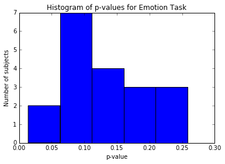

```python
%matplotlib inline
import matplotlib.pyplot as plt
import numpy as np
pvals = [0.10979589825845557, 0.090111620206697871, 0.09647191484053344, 0.064634545023686846, 0.12559871148843302, \
         0.083937043687263554, 0.1871166101885148, 0.14004915811061133, 0.25845529901162373, 0.013997517314439397, \
         0.14298535093029144, 0.25319145060463188, 0.12567512341631737, 0.099887945691406327, 0.20412957308308755, \
         0.03524601355027867, 0.22749767817533723, 0.17311820287068005, 0.098138682498457669]
plt.hist(pvals, 5)
plt.title('Histogram of p-values for Emotion Task')
plt.xlabel('p-value')
plt.ylabel('Number of subjects');
```

By saving the F values as a nifti image, we can view them as a brain. Here is an example of Subject 101107's F values viewed as a brain:

[figure not shown]

For the motor task, we obtain the following output for the mean p values:

Subject 101107: 0.1253047881874137  
Subject 102816: 0.046143916381061474  
Subject 102311: 0.013530707770316506  
Subject 103515: 0.029655558311241406  
Subject 106521: 0.1048393651297187  
Subject 108828: 0.035497329289684992  
Subject 111312: 0.084791400311045664  
Subject 111413: 0.065453650769658936  
Subject 113619: 0.07640979093939898  
Subject 116524: 0.010045612672973589  
Subject 118932: 0.075894229654992498  
Subject 120515: 0.028996876608796743  
Subject 123925: 0.022353294445433752  
Subject 130013: 0.048865274409958998  
Subject 166438: 0.029713312768130429  
Subject 171431: 0.0338449897064977  
Subject 180129: 0.056090160522639348  
Subject 255639: 0.10838160478783328  
Subject 293748: 0.093327693149852772  
Subject 204016: 0.081775204174863073

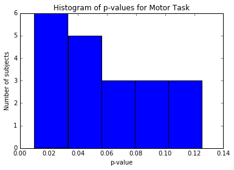

```python
%matplotlib inline
import matplotlib.pyplot as plt
import numpy as np
pvals = [0.1253047881874137, 0.046143916381061474, 0.013530707770316506, 0.029655558311241406, 0.1048393651297187, \
         0.035497329289684992, 0.084791400311045664, 0.065453650769658936, 0.07640979093939898, 0.010045612672973589, \
         0.075894229654992498, 0.028996876608796743, 0.022353294445433752, 0.048865274409958998, 0.029713312768130429, \
         0.0338449897064977, 0.056090160522639348, 0.10838160478783328, 0.093327693149852772, 0.081775204174863073]
plt.hist(pvals, 5)
plt.title('Histogram of p-values for Motor Task')
plt.xlabel('p-value')
plt.ylabel('Number of subjects');
```

Here is an example of Subject 101107's F values viewed as a brain:

[figure not shown]